# DataCamp_Intermediate-Data-Visualization-with-ggplot2

## Wrapping for many levels

`facet_grid()` is fantastic for categorical variables with a small number of levels. Although it is possible to facet variables with many levels, the resulting plot will be very wide or very tall, which can make it difficult to view.

The solution is to use `facet_wrap()` which separates levels along one axis but wraps all the subsets across a given number of rows or columns.

For this plot, we’ll use the `Vocab` dataset that we’ve already seen. The base layer is provided.

Since we have many years, it doesn’t make sense to use `facet_grid()`, so let’s try `facet_wrap()` instead.

### Instructions 1/3

Add a `facet_wrap()` layer and specify: The `year` variable with an argument using the `vars()` function,

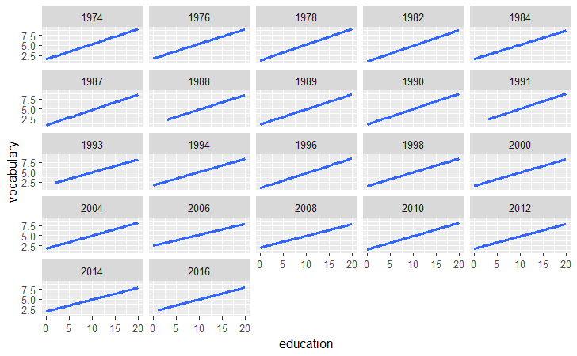

```r
library(carData)
data("Vocab")
ggplot(Vocab, aes(x = education, y = vocabulary)) +
  stat_smooth(method = "lm", se = FALSE) +
  # Create facets, wrapping by year, using vars()
  facet_wrap(vars(year))
```

### Instructions 2/3

Add a `facet_wrap()` layer and specify the year variable with a formula notation (`~`).

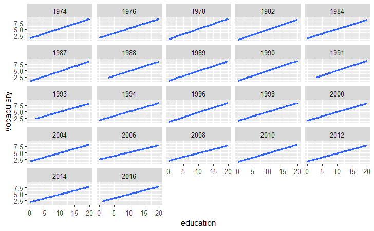

```r
ggplot(Vocab, aes(x = education, y = vocabulary)) +
  stat_smooth(method = "lm", se = FALSE) +
  # Create facets, wrapping by year, using a formula
  facet_wrap(~ year)
```

### Instructions 3/3

Add a `facet_wrap()` layer and specify: Formula notation as before, and `ncol` set to `11`.

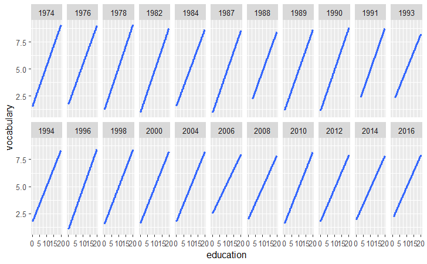

```r
ggplot(Vocab, aes(x = education, y = vocabulary)) +
  stat_smooth(method = "lm", se = FALSE) +
  # Update the facet layout, using 11 columns
  facet_wrap(~ year, ncol = 11)
```

## Margin plots

Facets are great for seeing subsets in a variable, but sometimes you want to see both those subsets and all values in a variable.

Here, the `margins` argument to `facet_grid()` is your friend.

- `FALSE` (default): no margins.
- `TRUE`: add margins to every variable being faceted by.
- `c("variable1", "variable2")`: only add margins to the variables listed.

To make it easier to follow the facets, we’ve created two factor variables with proper labels — `fam` for the transmission type, and `fvs` for the engine type, respectively.

Zoom the graphics window to better view your plots.

### Instructions 1/4

Update the plot to facet the rows by fvs and fam, and columns by gear.

```r
# ggplot(mtcars, aes(x = wt, y = mpg)) +
#   geom_point() +
#   # Facet rows by fvs and cols by fam
#   facet_grid(rows = vars(fvs, fam), cols = vars(gear))
```

### 2/4

Add all possible margins to the plot.

```r
# ggplot(mtcars, aes(x = wt, y = mpg)) +
#   geom_point() +
#   # Update the facets to add margins
#   facet_grid(rows = vars(fvs, fam), cols = vars(gear), margins = TRUE)
```

### 3/4

Update the facets to only show margins on “fam”.

```r
# ggplot(mtcars, aes(x = wt, y = mpg)) +
#   geom_point() +
#   # Update the facets to only show margins on fam
#   facet_grid(rows = vars(fvs, fam), cols = vars(gear), margins = "fam")
```

### 4/4

Update the facets to only show margins on “gear” and “fvs”.

```r
# ggplot(mtcars, aes(x = wt, y = mpg)) +
#   geom_point() +
#   # Update the facets to only show margins on gear and fvs
#   facet_grid(rows = vars(fvs, fam), cols = vars(gear), margins = c("gear", "fvs"))
```

# Chapter 4: Data Viz Best Practices

## Video 4.1: Best practices, bar plots

In this chapter:

- Common pitfalls in data viz
- Best way to represent data
  - For effective explanatory (communication), and
  - for effective exploratory (investigation) plots

### Bar plots

Two types:

- Absolute values
- Distributions

```r
data(msleep)
sleep <- msleep[, c("vore", "sleep_total", "sleep_rem")] %>%
  rename(total = sleep_total, rem = sleep_rem)

str(sleep)
```

```
tibble [83 × 3] (S3: tbl_df/tbl/data.frame)
 $ vore : chr [1:83] "carni" "omni" "herbi" "omni" ...
 $ total: num [1:83] 12.1 17 14.4 14.9 4 14.4 8.7 7 10.1 3 ...
 $ rem  : num [1:83] NA 1.8 2.4 2.3 0.7 2.2 1.4 NA 2.9 NA ...
```

### Dynamite Plot

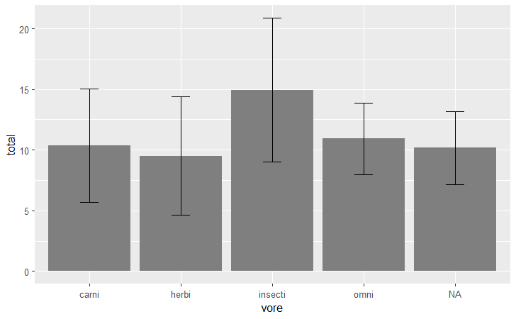

```r
d <- ggplot(sleep, aes(vore, total))

  # ...

d +
  stat_summary(fun = mean,
               geom = "bar",
               fill = "grey50") +
  stat_summary(fun.data = mean_sdl,
               fun.args = list(mult = 1),
               geom = "errorbar",
               width = 0.2)
```

### Individual data points

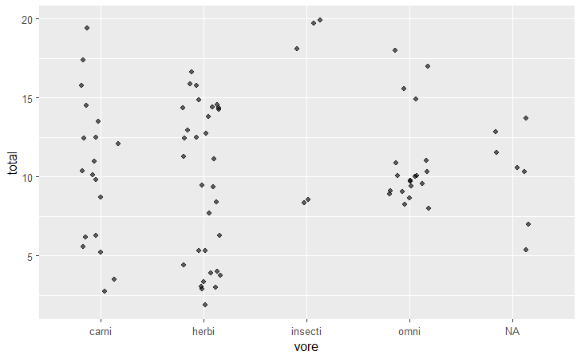

```r
# position
posn_j <- position_jitter(width = 0.2)

# plot
d +
    geom_point(alpha = 0.6,
               position = posn_j)
```

### `geom_errorbar()`

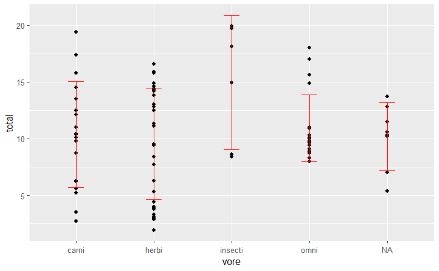

```r
d +
  geom_point() +
  stat_summary(fun = mean,
               geom = "point",
               fill = "red") +
  stat_summary(fun.data = mean_sdl,
               fun.args = list(mult = 1),
               geom = "errorbar",
               width = 0.2,
               color = "red")
```

### `geom_pointrange()`

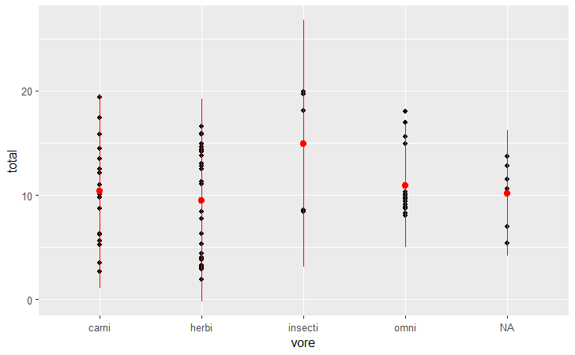

```r
d +
  geom_point() +
  stat_summary(fun.data = mean_sdl,
               mult = 1,
               width = 0.2,
               color = "red")
```

### Without data points

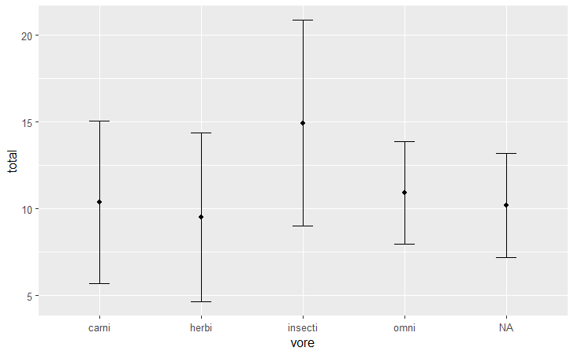

```r
d +
  stat_summary(fun = mean,
               geom = "point") +
  stat_summary(fun.data = mean_sdl,
               fun.args = list(mult = 1),
               geom = "errorbar",
               width = 0.2)
```

## Heatmaps use case scenario

### The `barley` dataset

```r
library(lattice)
head(barley, 9)
```

|  | yield | variety | year | site |
| --- | --- | --- | --- | --- |
| 1 | 27.00000 | Manchuria | 1931 | University Farm |
| 2 | 48.86667 | Manchuria | 1931 | Waseca |
| 3 | 27.43334 | Manchuria | 1931 | Morris |
| 4 | 39.93333 | Manchuria | 1931 | Crookston |
| 5 | 32.96667 | Manchuria | 1931 | Grand Rapids |
| 6 | 28.96667 | Manchuria | 1931 | Duluth |
| 7 | 43.06666 | Glabron | 1931 | University Farm |
| 8 | 55.20000 | Glabron | 1931 | Waseca |
| 9 | 28.76667 | Glabron | 1931 | Morris |

### A basic heat map

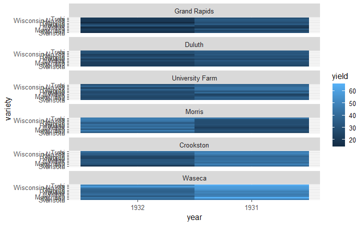

```r
ggplot(barley, aes(year, variety,
                   fill = yield)) +
  geom_tile() +
  facet_wrap(vars(site), ncol = 1)
```

### A dot plot

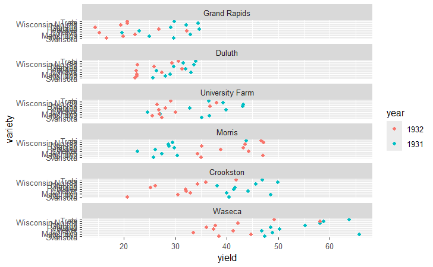

```r
ggplot(barley, aes(yield, variety,
                   color = year)) +
  geom_point() +
  facet_wrap(vars(site), ncol = 1)
```

### As a time series

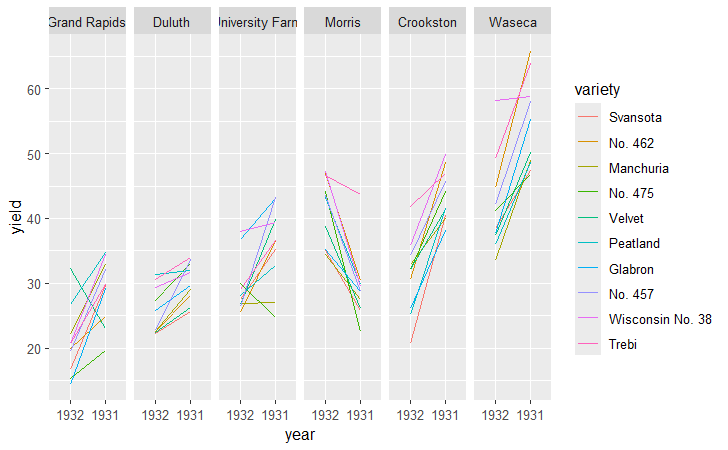

```r
ggplot(barley, aes(year, yield,
                   group = variety,
                   color = variety)) +
  geom_line() +
  facet_wrap(vars(site), nrow = 1)
```